# ArchR

https://www.archrproject.com/articles/Articles/tutorial.html

これは簡単な ArchR のチュートリアルで、ArchR のすべての機能を紹介するものではありませんし、それぞれのステップを詳細に説明するものでもありません。 実際のデータを使った詳細なチュートリアルや ArchR の分析の全側面についての説明は[フルユーザーズマニュアル](https://www.archrproject.com/articles/Articles/bookdown/index.html)をご覧ください。

```r
library(ArchR)
set.seed(1)
```

```r
addArchRThreads(threads = 16)
```

```
Setting default number of Parallel threads to 16.
```

```r
# Download the Hematopoeisis tutorial data
inputFiles <- getTutorialData("Hematopoiesis")
inputFiles
```

```
                                      scATAC_BMMC_R1
     "HemeFragments/scATAC_BMMC_R1.fragments.tsv.gz"
                                 scATAC_CD34_BMMC_R1
"HemeFragments/scATAC_CD34_BMMC_R1.fragments.tsv.gz"
                                      scATAC_PBMC_R1
     "HemeFragments/scATAC_PBMC_R1.fragments.tsv.gz"
```

```r
addArchRGenome("hg19")
```

```
Setting default genome to Hg19.
```

## Creating Arrow Files

Now we will create our Arrow files which will take 10-15 minutes. For each sample, this step will:

- Read accessible fragments from the provided input files.
- Calculate quality control information for each cell (i.e. TSS enrichment scores and nucleosome info).
- Filter cells based on quality control parameters.
- Create a genome-wide TileMatrix using 500-bp bins.
- Create a GeneScoreMatrix using the custom geneAnnotation that was defined when we called addArchRGenome().

```r
ArrowFiles <- createArrowFiles(
  inputFiles = inputFiles,
  sampleNames = names(inputFiles),
  filterTSS = 4, #Dont set this too high because you can always increase later
  filterFrags = 1000,
  addTileMat = TRUE,
  addGeneScoreMat = TRUE
)
```

```
Using GeneAnnotation set by addArchRGenome(Hg19)!
Using GeneAnnotation set by addArchRGenome(Hg19)!
ArchR logging to : ArchRLogs/ArchR-createArrows-1123419e170e-Date-2020-06-12_Time-12-09-43.log
If there is an issue, please report to github with logFile!
Cleaning Temporary Files
2020-06-12 12:09:43 : Batch Execution w/ safelapply!, 0 mins elapsed.
(scATAC_BMMC_R1 : 1 of 3) Checking if completed file exists!
2020-06-12 12:09:44 : (scATAC_BMMC_R1 : 1 of 3) Arrow Exists! Marking as completed since force = FALSE!, 0.002 mins elapsed.
(scATAC_CD34_BMMC_R1 : 2 of 3) Checking if completed file exists!
2020-06-12 12:09:44 : (scATAC_CD34_BMMC_R1 : 2 of 3) Arrow Exists! Marking as completed since force = FALSE!, 0.002 mins elapsed.
(scATAC_PBMC_R1 : 3 of 3) Checking if completed file exists!
2020-06-12 12:09:44 : (scATAC_PBMC_R1 : 3 of 3) Arrow Exists! Marking as completed since force = FALSE!, 0.003 mins elapsed.
ArchR logging successful to : ArchRLogs/ArchR-createArrows-1123419e170e-Date-2020-06-12_Time-12-09-43.log
```

```r
ArrowFiles
```

```
[1] "scATAC_BMMC_R1.arrow"      "scATAC_CD34_BMMC_R1.arrow"
[3] "scATAC_PBMC_R1.arrow"
```

scATAC-seqデータの厳密な品質管理（QC）は、低品質の細胞の寄与を取り除くために不可欠です。ArchRでは、データの3つの特徴を考慮しています。

- ゲノムにマップされるリードの数（すなわち、ミトコンドリアDNAにマッピングされていない）。
- The signal-to-background ratio. シグナル対バックグラウンド比が低いのは、死んだ細胞や死にかけている細胞が、ゲノム全体のランダムなトランスポジションを可能にする脱クロマチン化されたDNAを持っていることが原因であることが多いです。
- フラグメントサイズの分布。ヌクレオソームの周期性により、ヌクレオソームに巻きついたDNAの長さ（約147bp）のフラグメントが枯渇していることが予想されます。

## Inferring Doublets

Arrowファイルの作成後、下流の結果を混乱させる可能性のある潜在的なダブレット（複数のセルを含む単一の液滴）を推論することができます。これは `addDoubletScores()` 関数を使用して行います。

```r
doubScores <- addDoubletScores(
  input = ArrowFiles,
  k = 10, #Refers to how many cells near a "pseudo-doublet" to count.
  knnMethod = "UMAP", #Refers to the embedding to use for nearest neighbor search.
  LSIMethod = 1
)
```

```
ArchR logging to : ArchRLogs/ArchR-addDoubletScores-112354d1b3d8-Date-2020-06-12_Time-12-09-44.log
If there is an issue, please report to github with logFile!
2020-06-12 12:09:44 : Batch Execution w/ safelapply!, 0 mins elapsed.
2020-06-12 12:09:44 : scATAC_BMMC_R1 (1 of 3) :  Computing Doublet Statistics, 0 mins elapsed.
scATAC_BMMC_R1 (1 of 3) : UMAP Projection R^2 = 0.9801
scATAC_BMMC_R1 (1 of 3) : UMAP Projection R^2 = 0.9801
```

[output not shown]

[output not shown]

[output not shown]

[output not shown]

[output not shown]

[output not shown]

## Creating an ArchRProject

With our Arrow files in hand, we are now ready to create an ArchRProject. An ArchRProject is associated with a set of Arrow files and is the backbone of nearly all ArchR analyses.

```r
proj <- ArchRProject(
  ArrowFiles = ArrowFiles,
  outputDirectory = "HemeTutorial",
  copyArrows = TRUE #This is recommened so that you maintain an unaltered copy for later usage.
)
```

[output not shown]

```r
getAvailableMatrices(proj)
```

```
[1] "GeneScoreMatrix" "TileMatrix"
```

```r
proj <- filterDoublets(ArchRProj = proj)
```

```
Filtering 410 cells from ArchRProject!
    scATAC_BMMC_R1 : 243 of 4932 (4.9%)
    scATAC_CD34_BMMC_R1 : 107 of 3275 (3.3%)
    scATAC_PBMC_R1 : 60 of 2454 (2.4%)
```

## Dimensionality Reduction and Clustering

ArchR implements an iterative LSI dimensionality reduction via the addIterativeLSI() function.

```r
proj <- addIterativeLSI(ArchRProj = proj, useMatrix = "TileMatrix", name = "IterativeLSI")
```

```
Checking Inputs...
ArchR logging to : ArchRLogs/ArchR-addIterativeLSI-11237c83044e-Date-2020-06-12_Time-12-14-04.log
If there is an issue, please report to github with logFile!
2020-06-12 12:14:04 : Computing Total Accessibility Across All Features, 0.003 mins elapsed.
2020-06-12 12:14:07 : Computing Top Features, 0.048 mins elapsed.
###########
2020-06-12 12:14:08 : Running LSI (1 of 2) on Top Features, 0.057 mins elapsed.
###########
2020-06-12 12:14:08 : Sampling Cells (N = 10002) for Estimated LSI, 0.058 mins elapsed.
2020-06-12 12:14:08 : Creating Sampled Partial Matrix, 0.058 mins elapsed.
2020-06-12 12:14:14 : Computing Estimated LSI (projectAll = FALSE), 0.163 mins elapsed.
2020-06-12 12:15:03 : Identifying Clusters, 0.981 mins elapsed.
2020-06-12 12:15:28 : Identified 5 Clusters, 1.397 mins elapsed.
2020-06-12 12:15:28 : Saving LSI Iteration, 1.397 mins elapsed.
```

To call clusters in this reduced dimension sub-space, we use the addClusters() function which uses Seurat’s graph clustering as the default clustering method.

```r
proj <- addClusters(input = proj, reducedDims = "IterativeLSI")
```

```
ArchR logging to : ArchRLogs/ArchR-addClusters-112330880478-Date-2020-06-12_Time-12-16-40.log
If there is an issue, please report to github with logFile!
2020-06-12 12:16:40 : Running Seurats FindClusters (Stuart et al. Cell 2019), 0.001 mins elapsed.
```

```
Modularity Optimizer version 1.3.0 by Ludo Waltman and Nees Jan van Eck

Number of nodes: 10251
Number of edges: 497945

Running Louvain algorithm...
```

```
Maximum modularity in 10 random starts: 0.8547
Number of communities: 11
Elapsed time: 1 seconds
```

```
2020-06-12 12:17:01 : Testing Outlier Clusters, 0.357 mins elapsed.
2020-06-12 12:17:01 : Assigning Cluster Names to 11 Clusters, 0.357 mins elapsed.
2020-06-12 12:17:01 : Finished addClusters, 0.358 mins elapsed.
```

## Visualizing in a 2D UMAP

```r
proj <- addUMAP(ArchRProj = proj, reducedDims = "IterativeLSI")
```

```r
p1 <- plotEmbedding(ArchRProj = proj, colorBy = "cellColData", name = "Sample", embedding = "UMAP")
```

```
ArchR logging to : ArchRLogs/ArchR-plotEmbedding-112320583931-Date-2020-06-12_Time-12-17-16.log
If there is an issue, please report to github with logFile!
Getting UMAP Embedding
```

[output not shown]

```
ColorBy = cellColData
Plotting Embedding
1
ArchR logging successful to : ArchRLogs/ArchR-plotEmbedding-112320583931-Date-2020-06-12_Time-12-17-16.log
```

```r
p2 <- plotEmbedding(ArchRProj = proj, colorBy = "cellColData", name = "Clusters", embedding = "UMAP")
```

```
ArchR logging to : ArchRLogs/ArchR-plotEmbedding-11239fd4021-Date-2020-06-12_Time-12-17-16.log
If there is an issue, please report to github with logFile!
Getting UMAP Embedding
```

[output not shown]

```
ColorBy = cellColData
Plotting Embedding
1
ArchR logging successful to : ArchRLogs/ArchR-plotEmbedding-11239fd4021-Date-2020-06-12_Time-12-17-16.log
```

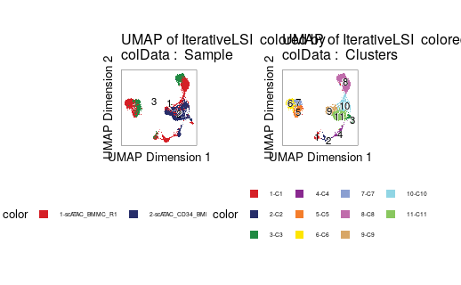

```r
ggAlignPlots(p1, p2, type = "h")
```

```r
plotPDF(p1,p2, name = "Plot-UMAP-Sample-Clusters.pdf",
        ArchRProj = proj, addDOC = FALSE, width = 5, height = 5)
```

```
Plotting Ggplot!
```

## Assigning Clusters with Gene Scores

```r
proj <- addImputeWeights(proj)
```

```
ArchR logging to : ArchRLogs/ArchR-addImputeWeights-1123ea2e257-Date-2020-06-12_Time-12-17-25.log
If there is an issue, please report to github with logFile!
2020-06-12 12:17:25 : Computing Impute Weights Using Magic (Cell 2018), 0 mins elapsed.
```

```r
markerGenes  <- c(
    "CD34",  #Early Progenitor
    "GATA1", #Erythroid
    "PAX5", "MS4A1", "MME", #B-Cell Trajectory
    "CD14", "MPO", #Monocytes
    "CD3D", "CD8A"#TCells
  )

p <- plotEmbedding(
    ArchRProj = proj,
    colorBy = "GeneScoreMatrix",
    name = markerGenes,
    embedding = "UMAP",
    imputeWeights = getImputeWeights(proj)
)
```

```
Getting ImputeWeights
ArchR logging to : ArchRLogs/ArchR-plotEmbedding-11231abbd3a0-Date-2020-06-12_Time-12-17-35.log
If there is an issue, please report to github with logFile!
Getting UMAP Embedding
```

[output not shown]

```
ColorBy = GeneScoreMatrix
Getting Matrix Values...
2020-06-12 12:17:36 :
1 2 3
Imputing Matrix
Using weights on disk
1 of 2
2 of 2
Using weights on disk
1 of 2
2 of 2
Plotting Embedding
1 2 3 4 5 6 7 8 9
ArchR logging successful to : ArchRLogs/ArchR-plotEmbedding-11231abbd3a0-Date-2020-06-12_Time-12-17-35.log
```

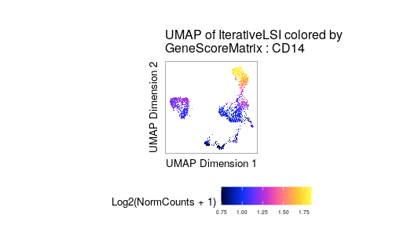

```r
p$CD14
```

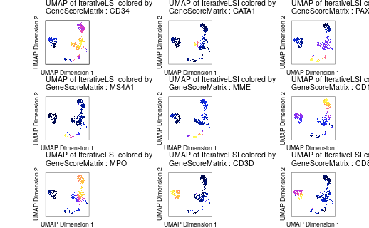

```r
#Rearrange for grid plotting
p2 <- lapply(p, function(x){
    x + guides(color = FALSE, fill = FALSE) +
    theme_ArchR(baseSize = 6.5) +
    theme(plot.margin = unit(c(0, 0, 0, 0), "cm")) +
    theme(
        axis.text.x=element_blank(),
        axis.ticks.x=element_blank(),
        axis.text.y=element_blank(),
        axis.ticks.y=element_blank()
    )
})
do.call(cowplot::plot_grid, c(list(ncol = 3),p2))
```

```r
plotPDF(plotList = p,
    name = "Plot-UMAP-Marker-Genes-W-Imputation.pdf",
    ArchRProj = proj,
    addDOC = FALSE, width = 5, height = 5)
```

```
Plotting Ggplot!
```

## Visualizing Genome Browser Tracks

In addition to plotting gene scores per cell as a UMAP overlay, we can browse the local chromatin accessibility at these marker genes on a per cluster basis with genome browser tracks. To do this, we use the plotBrowserTrack() function which will create a list of plots, one for each of the genes specified by markerGenes.

```r
p <- plotBrowserTrack(
    ArchRProj = proj,
    groupBy = "Clusters",
    geneSymbol = markerGenes,
    upstream = 50000,
    downstream = 50000
)
```

```
ArchR logging to : ArchRLogs/ArchR-plotBrowserTrack-1123498c7f94-Date-2020-06-12_Time-12-18-05.log
If there is an issue, please report to github with logFile!
2020-06-12 12:18:05 : Validating Region, 0.003 mins elapsed.
```

```
GRanges object with 9 ranges and 2 metadata columns:
      seqnames              ranges strand |     gene_id
         <Rle>           <IRanges>  <Rle> | <character>
  [1]     chr1 208059883-208084683      - |         947
  [2]     chrX   48644982-48652717      + |        2623
  [3]     chr9   36838531-37034476      - |        5079
  [4]    chr11   60223282-60238225      + |         931
  [5]     chr3 154741913-154901518      + |        4311
  [6]     chr5 140011313-140013286      - |         929
  [7]    chr17   56347217-56358296      - |        4353
  [8]    chr11 118209789-118213459      - |         915
  [9]     chr2   87011728-87035519      - |         925
           symbol
      <character>
  [1]        CD34
  [2]       GATA1
  [3]        PAX5
  [4]       MS4A1
  [5]         MME
  [6]        CD14
  [7]         MPO
  [8]        CD3D
  [9]        CD8A
  -------
  seqinfo: 24 sequences from hg19 genome
```

```
2020-06-12 12:18:06 : Adding Bulk Tracks (1 of 9), 0.004 mins elapsed.
Getting Region From Arrow Files 1 of 3
Getting Region From Arrow Files 2 of 3
Getting Region From Arrow Files 3 of 3
```

[output not shown]

[output not shown]

[output not shown]

[output not shown]

[output not shown]

[output not shown]

[output not shown]

[output not shown]

[output not shown]

[output not shown]

[output not shown]

```
2020-06-12 12:18:06 : Adding Gene Tracks (1 of 9), 0.018 mins elapsed.
2020-06-12 12:18:07 : Plotting, 0.024 mins elapsed.
2020-06-12 12:18:09 : Adding Bulk Tracks (2 of 9), 0.061 mins elapsed.
Getting Region From Arrow Files 1 of 3
Getting Region From Arrow Files 2 of 3
Getting Region From Arrow Files 3 of 3
```

[output not shown]

[output not shown]

[output not shown]

[output not shown]

[output not shown]

[output not shown]

[output not shown]

[output not shown]

[output not shown]

[output not shown]

[output not shown]

```
2020-06-12 12:18:10 : Adding Gene Tracks (2 of 9), 0.07 mins elapsed.
2020-06-12 12:18:10 : Plotting, 0.075 mins elapsed.
2020-06-12 12:18:12 : Adding Bulk Tracks (3 of 9), 0.107 mins elapsed.
Getting Region From Arrow Files 1 of 3
Getting Region From Arrow Files 2 of 3
Getting Region From Arrow Files 3 of 3
```

[output not shown]

[output not shown]

[output not shown]

[output not shown]

[output not shown]

[output not shown]

[output not shown]

[output not shown]

[output not shown]

[output not shown]

[output not shown]

```
2020-06-12 12:18:12 : Adding Gene Tracks (3 of 9), 0.117 mins elapsed.
2020-06-12 12:18:13 : Plotting, 0.121 mins elapsed.
2020-06-12 12:18:15 : Adding Bulk Tracks (4 of 9), 0.158 mins elapsed.
Getting Region From Arrow Files 1 of 3
Getting Region From Arrow Files 2 of 3
Getting Region From Arrow Files 3 of 3
```

[output not shown]

[output not shown]

[output not shown]

[output not shown]

[output not shown]

[output not shown]

[output not shown]

[output not shown]

[output not shown]

[output not shown]

[output not shown]

```
2020-06-12 12:18:15 : Adding Gene Tracks (4 of 9), 0.168 mins elapsed.
2020-06-12 12:18:16 : Plotting, 0.172 mins elapsed.
2020-06-12 12:18:17 : Adding Bulk Tracks (5 of 9), 0.197 mins elapsed.
Getting Region From Arrow Files 1 of 3
Getting Region From Arrow Files 2 of 3
Getting Region From Arrow Files 3 of 3
```

[output not shown]

[output not shown]

[output not shown]

[output not shown]

[output not shown]

[output not shown]

[output not shown]

[output not shown]

[output not shown]

[output not shown]

[output not shown]

```
2020-06-12 12:18:18 : Adding Gene Tracks (5 of 9), 0.207 mins elapsed.
2020-06-12 12:18:18 : Plotting, 0.211 mins elapsed.
2020-06-12 12:18:19 : Adding Bulk Tracks (6 of 9), 0.235 mins elapsed.
Getting Region From Arrow Files 1 of 3
Getting Region From Arrow Files 2 of 3
Getting Region From Arrow Files 3 of 3
```

[output not shown]

[output not shown]

[output not shown]

[output not shown]

[output not shown]

[output not shown]

[output not shown]

[output not shown]

[output not shown]

[output not shown]

[output not shown]

```
2020-06-12 12:18:20 : Adding Gene Tracks (6 of 9), 0.246 mins elapsed.
2020-06-12 12:18:20 : Plotting, 0.25 mins elapsed.
2020-06-12 12:18:23 : Adding Bulk Tracks (7 of 9), 0.287 mins elapsed.
Getting Region From Arrow Files 1 of 3
Getting Region From Arrow Files 2 of 3
Getting Region From Arrow Files 3 of 3
```

[output not shown]

[output not shown]

[output not shown]

[output not shown]

[output not shown]

[output not shown]

[output not shown]

[output not shown]

[output not shown]

[output not shown]

[output not shown]

```
2020-06-12 12:18:23 : Adding Gene Tracks (7 of 9), 0.297 mins elapsed.
2020-06-12 12:18:23 : Plotting, 0.302 mins elapsed.
2020-06-12 12:18:26 : Adding Bulk Tracks (8 of 9), 0.343 mins elapsed.
Getting Region From Arrow Files 1 of 3
Getting Region From Arrow Files 2 of 3
Getting Region From Arrow Files 3 of 3
```

[output not shown]

[output not shown]

[output not shown]

[output not shown]

[output not shown]

[output not shown]

[output not shown]

[output not shown]

[output not shown]

[output not shown]

[output not shown]

```
2020-06-12 12:18:27 : Adding Gene Tracks (8 of 9), 0.353 mins elapsed.
2020-06-12 12:18:27 : Plotting, 0.357 mins elapsed.
2020-06-12 12:18:29 : Adding Bulk Tracks (9 of 9), 0.391 mins elapsed.
Getting Region From Arrow Files 1 of 3
Getting Region From Arrow Files 2 of 3
Getting Region From Arrow Files 3 of 3
```

[output not shown]

[output not shown]

[output not shown]

[output not shown]

[output not shown]

[output not shown]

[output not shown]

[output not shown]

[output not shown]

[output not shown]

[output not shown]

```
2020-06-12 12:18:30 : Adding Gene Tracks (9 of 9), 0.403 mins elapsed.
2020-06-12 12:18:30 : Plotting, 0.407 mins elapsed.
ArchR logging successful to : ArchRLogs/ArchR-plotBrowserTrack-1123498c7f94-Date-2020-06-12_Time-12-18-05.log
```

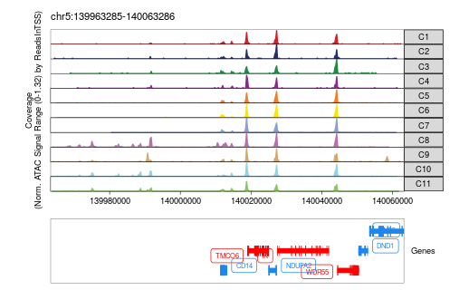

```r
grid::grid.newpage()
grid::grid.draw(p$CD14)
```

```r
plotPDF(plotList = p,
    name = "Plot-Tracks-Marker-Genes.pdf",
    ArchRProj = proj,
    addDOC = FALSE, width = 5, height = 5)
```

```
Plotting Gtable!
```

```r
ArchRBrowser(ArchRProj = proj)
```

```
ArchR logging to : ArchRLogs/ArchR-ArchRBrowser-112335657141-Date-2020-06-12_Time-12-18-36.log
If there is an issue, please report to github with logFile!

Listening on http://127.0.0.1:7932
```

```
NA
```

## Saving and Loading an ArchRProject

To easily save an ArchRProject for later use or for sharing with collaborators, we use the saveArchRProject() function. This copies the current ArchRProject object and all of the Arrow files to a specified directory. If we don’t specify an output directory (as below), saveArchRProject() uses the output directory that we specified upon creation of our ArchRProject. In this case that is the folder “HemeTutorial”.

```r
proj <- saveArchRProject(ArchRProj = proj)
```

[output not shown]

When we are ready to load this saved ArchRProject we use the loadArchRProject() object and provide the path to the folder containing the saved ArchRProject object.

```r
proj <- loadArchRProject(path = "HemeTutorial")
```

[output not shown]

## Session Information

```r
Sys.Date()
```

```
[1] "2020-06-12"
```